# Webscraper

**Nota Bene: The scraper for Fotocasa.es is the one in py. format. This file, more specific, section 1 is used for testing. All the other scrapers (those for other websites) are inside this file, i.e., not a testing version, but the real ones. Each Scraper has its own Section.**

```python
# ========================= Selenium packages: =========================
from webdriver_manager.chrome import ChromeDriverManager
from selenium import webdriver # resposible for giving and controlling access to a webdriver
from selenium.webdriver.common.by import By # provides set of methods for locating web elements on webpage
from selenium.webdriver.support.ui import WebDriverWait # Will be used to wait some element appear before searching for it.
from selenium.webdriver.support import expected_conditions as EC
from selenium.webdriver import ActionChains # will be used to open a link in an extra-tab
from selenium.webdriver.common.keys import Keys
from selenium.common.exceptions import *
import re #
import numbers
from decimal import Decimal # will be used to round up values to the next 0.5 (Ex. 1.3 –> 1.5)
#from code.booking_filtration import BookingFiltration
import time
#from code.report import BookingReport
import pandas as pd
import numpy as np
import os
import inspect # module will be used to inspect which arguments have been passed to a function
import pandas as pd
import datetime
# ========================= Beautiful Soup packages: =========================
from bs4 import BeautifulSoup
import requests
import os
import pandas as pd
import random
import time
import numpy as np
import csv
from urllib.parse import urljoin
from Scraper.functions import *
from selenium.webdriver.common.desired_capabilities import DesiredCapabilities
```

- **Step 0:** Selenium Options: They are important in order for the website not to give us captcha:

```python
# {1}: Specify where your chromedriver is and pass it to your home-path
driver_path = r'/Users/ferreira/Desktop'
os.environ['PATH'] = driver_path
# {2}: create a chrome option element
option = webdriver.ChromeOptions()
option.add_argument('--disable-blink-features=AutomationControlled')
option.add_argument("window-size=1280, 800")
option.add_argument("user-agent=Mozilla/5.0 (Windows NT 10.0; Win64;"\
                    + "x64)AppleWebKit/537.36 (KHTML, like Gecko)"\
                    + "Chrome/74.0.3729.169 Safari/537.36")
#option.add_argument(f'user-agent={random.choice(user_agent_list)}')
#option.add_argument("--enable-javascript")
#capabilities = DesiredCapabilities().CHROME.copy()

# Set JavaScript enabled in DesiredCapabilities
#capabilities["javascriptEnabled"] = True

# {3}: pass the settings to the driver and open it
#option.add_experimental_option("excludeSwitches", ["enable-automation",
                                                           #'disable-component-update',
                                                           #'ignore-certificate-errors'])
#option.add_experimental_option('useAutomationExtension', False)
#option.add_argument("--headless")
```

# **1. Webscraper [Fotocasa.es](https://www.fotocasa.es/es/)**

## **1.1. Initial Page:**

- **Step 1**: Require connection to the page:

```python
url = 'https://www.fotocasa.es/es/'
driver = webdriver.Chrome(options=option, desired_capabilities=capabilities)
driver.get(url)
#driver.maximize_window()
driver.execute_script("Object.defineProperty(navigator, 'webdriver', {get: () => undefined})")
```

- **Step 2:** Check for Cookies and Accept them

```python
wait = WebDriverWait(driver, 10)
# {1} We will use expected conditions to check whether a cookie box appear. If it does not, out code will move on
try:
    cookies_element = wait.until(EC.element_to_be_clickable((By.CSS_SELECTOR, 'button[data-testid="TcfAccept"]')))
    cookies_element.click()
except TimeoutException as e:
    print('TimeoutException happened.')
    pass
finally:
    pass
```

- **Step 3:** Decide whether on your type of action: {buy, rent, new construction, share}-property:

```python
action = 'buy'
class_keys = {'buy': 'buy', 'rent': 'rent', 'new construction': 'FILTER_CONSERVATION_STATUS_NEW_HOME', 'share': 'share'}
core_class = f"re-HomeSearchSelector-item re-HomeSearchSelector-item--{class_keys[action]}"
action_element = driver.find_element(By.CSS_SELECTOR, f'div[class="{core_class}"]')
action_element.click()
```

- **Step 4:** Insert an address.

```python
address = 'Nerva, Huelva'
placeholder_element = driver.find_element(By.CSS_SELECTOR, 'input[placeholder]')
placeholder_element.send_keys(address)
```

If needed, click on the close button to redo querry

```python
close = driver.find_element(By.CSS_SELECTOR,
                            'span[class="sui-MoleculeAutosuggest-input-clear-icon"]')

close.click()
```

```python
# Find Listbox
listbox = driver.find_element(By.CSS_SELECTOR, 'ul[role="listbox"]')
```

```python
options = listbox.find_elements(By.CSS_SELECTOR, 'li[data-value]')
for i in options:
    print(i.text)
```

```
Nerva, Huelva
Ciudad
```

```python
large_list = driver.find_element(By.TAG_NAME, 'ul').find_elements(By.TAG_NAME, 'li')
query = 'Alameda, Málaga, Ciudad'
for i, opt in enumerate(large_list):
    if 'Alameda'.lower() in opt.text.lower() and 'Málaga'.lower() in opt.text.lower() and 'Ciudad'.lower() in opt.text.lower():
        print(i, 'yes')
        j = i
```

```
1 yes
```

- **Step 5:** other-options

```python
# {1}: Fist find the bottun with the list of options
option = 'housing'
options_lister = driver.find_element(By.CSS_SELECTOR, 'select[title="Seleccione"]')

translation_options = {
    'housing': 'Vivienda',
    'new construction': 'Obra nueva',
    'promotions': 'Promociones',
    'commercial': 'Local y nave',
    'garage': 'Garaje',
    'office': 'Oficina',
    'storage-room': 'Trastero',
    'land': 'Terreno',
    'building': 'Edificio'
}


options = options_lister.find_elements(By.TAG_NAME, 'option')
index = [index for index, word in enumerate(options) if word.text == translation_options[option]]

option_button = options[index[0]].click()
```

```python
[index for index, word in enumerate(options)
                 if word.text == translation_options[option]]
```

```
[0]
```

- **Step 6:** Click on the search buttom

```python
submit_button = driver.find_element(By.CSS_SELECTOR, 'button[type="submit"]')
submit_button.click()
```

## **1.2. Page with List of Ads**

- **Step 1**: Find the adds in the page:

```python
# Find the table with the the list of adds. The adds are saved in the html code under "articles", we first only want the list with all
# articles for that page
ad_list_parent = wait.until(EC.presence_of_element_located((By.CSS_SELECTOR, 'section[class="re-SearchResult"]')))

# As the page only display the values when scrolled down, we will first scroll the whole page down.
counter = 0
scrolling = True
scroller = 200
while scrolling == True:

    try:
        scroller += 200
        Y = str(scroller)
        current_height = driver.execute_script('return window.pageYOffset')
        driver.execute_script(f"window.scrollTo(0, {Y})")
        new_height = driver.execute_script('return window.pageYOffset')
        time.sleep(0.2)

        if new_height == current_height:

            break
    except Exception:

        scrolling = False

# Now obtain the articles in the page
ad_list_articles = (
                    driver.find_element(By.CSS_SELECTOR, 'section[class="re-SearchResult"]')
                    .find_elements(By.TAG_NAME, 'article')
                   )

len(ad_list_articles)
```

```
31
```

- **Step 2:** Use BeautifulSoup to obtain the references to the adds.

```python
# Continue with BeautifulSoup:
source = driver.page_source
soup = BeautifulSoup(driver.page_source, 'html.parser')

# get all articles
articles = soup.find_all('article')

# now get all attribute tags in articles
base_url = 'https://www.fotocasa.es'
href = []
for elements in articles:
    absolute_url = urljoin(base_url, elements.find_all('a')[0]['href'])
    href.append(absolute_url)
len(href)
```

```
31
```

- **Step 3:** Surf to the next page:

```python
# First the the element holding all the buttons for the next page:
pager = driver.find_element(By.CLASS_NAME, 'sui-MoleculePagination')
# Now we find all buttons of the pager
buttons = pager.find_elements(By.TAG_NAME, 'li')

# Now get the text inside the buttons
text = []
for button in buttons:
    if (button.text.isdigit()):
        text.append(int(button.text))

# click in the next button to go to the next page
buttons[1].click()
text
```

```
[1, 2, 3, 4, 637]
```

- We will go up with the page:

```python
# Find the table with the the list of adds. The adds are saved in the html code under "articles", we first only want the list with all
# articles for that page
ad_list_parent = wait.until(EC.presence_of_element_located((By.CSS_SELECTOR, 'section[class="re-SearchResult"]')))

# As the page only display the values when scrolled down, we will first scroll the whole page down.
counter = 0
scrolling = True
scroller = 200
while scrolling == True:

    try:
        scroller += 200
        #Y = str(-scroller)
        current_height = driver.execute_script('return window.pageYOffset')
        execute_script("window.scrollBy(0,-1000)")
        new_height = driver.execute_script('return window.pageYOffset')
        time.sleep(0.10)

        if new_height == current_height:

            break
    except Exception:

        scrolling = False

# Now obtain the articles in the page
ad_list_articles = (
                    driver.find_element(By.CSS_SELECTOR, 'section[class="re-SearchResult"]')
                    .find_elements(By.TAG_NAME, 'article')
                   )

len(ad_list_articles)
```

```
31
```

```python
driver.execute_script("scrollBy(0,-2000);")
```

## Extra: Close Register Message:

Sometimes the website will send you a message telling you to register. We want to close that message in the case it happens.

```python
close_message_element = driver.find_element(By.CSS_SELECTOR, 'button[aria-label="Close Message"]')
close_message_element.click()
```

## **1.3. Inside an Ad**

- Proxy rotation:

```python
#res = requests.get('https://free-proxy-list.net')

#content = BeautifulSoup(res.text, 'lxml')

#table = content.find('table')

#rows = table.find_all('tr')

#cols = [[col.text for col in row.find_all('td')] for row in rows]

#proxies = []
proxies = pd.read_csv('proxies.csv')
proxies = proxies.values
proxies = [i[0] for i in proxies]
proxy_index = 0
#for col in cols:
    #try:
        #if col[4] == 'elite proxy' and col[6] == 'yes':
           # proxies.append('https://' +  col[0] + ':' + col[1])
    #except:
        #pass


def fetch(url, params):
    global proxy_index
    while proxy_index < len(proxies):
        try:
            print('Trying proxy:', proxies[proxy_index])
            res = requests.get(url, proxies = {'https': proxies[proxy_index]}, params = params, timeout = 5)
            return res

        except:
            print('Bad proxy ...')
            proxy_index += 1

url = 'https://www.fotocasa.es/es/comprar/vivienda/obra-nueva/la-puebla-de-alfinden/19663061/161806371?from=list'
for page in range(0, 4):
    params = {'page': page}

    res = fetch(url, params = params)
    proxy_index += 1
    #print('ip:', res.json()['ip'])
    #print('url:', res.json()['url'])
```

```
Trying proxy: 128.140.63.206:8080
Trying proxy: 139.162.14.86:80
Bad proxy ...
Trying proxy: 209.38.238.247:8080
Trying proxy: 167.99.116.111:8000
Bad proxy ...
Trying proxy: 47.91.56.120:9002
Bad proxy ...
Trying proxy: 115.171.217.15:7890
Trying proxy: 104.248.195.138:80
Bad proxy ...
Trying proxy: 209.38.244.34:8080
```

- We will use BeautifulSoup to obtain Attributes from Inside the Ad.

```python
# Create a dictionary to obtain the attributes
attributes = {}
```

```python
api = '######'
proxy_list = requests.get(api)
proxies = proxy_list.text.split('\n')
df_UA = pd.read_csv('00_USerAgents.csv', header = None)

user_agent_list = [UA[0] for UA in df_UA.values.tolist()]
```

```python
url = 'https://www.fotocasa.es/es/comprar/vivienda/obra-nueva/la-puebla-de-alfinden/19663061/161806371?from=list'
from bs4 import BeautifulSoup
from urllib.request import urlopen, Request
import random
"""user_agent_list = [
    'Mozilla/5.0 (Windows NT 10.0; Win64; x64) AppleWebKit/537.36 (KHTML, like Gecko) Chrome/109.0.0.0 Safari/537.36',
    'Mozilla/5.0 (Macintosh; Intel Mac OS X 10_15_7) AppleWebKit/537.36 (KHTML, like Gecko) Chrome/108.0.0.0 Safari/537.36',
    'Mozilla/5.0 (Macintosh; Intel Mac OS X 13_1) AppleWebKit/605.1.15 (KHTML, like Gecko) Version/16.1 Safari/605.1.15',
    'Mozilla/5.0 (Windows NT 10.0; Win64; x64) AppleWebKit/537.36 (KHTML, like Gecko) Chrome/88.0.4324.182 Safari/537.36',
    'Mozilla/5.0 (iPad; CPU OS 12_2 like Mac OS X) AppleWebKit/605.1.15 (KHTML, like Gecko) Mobile/15E148'
    ]"""

while True:

    try:
        #HEADERS = {}
        api = '#######'
        proxy_list = requests.get(api)
        proxies = proxy_list.text.split('\n')
        """headers = {'User-Agent': 'Mozilla/5.0 (X11; Linux x86_64) '
                                'AppleWebKit/537.11 (KHTML, like Gecko) '
                                'Chrome/23.0.1271.64 Safari/537.11',
                    'Accept': 'text/html,application/xhtml+xml,application/xml;q=0.9,*/*;q=0.8',
                    'Accept-Charset': 'ISO-8859-1,utf-8;q=0.7,*;q=0.3',
                    'Accept-Encoding': 'none',
                    'Accept-Language': 'en-US,en;q=0.8',
                    'Connection': 'keep-alive'}
        """
        headers = {"user-agent": "Mozilla/5.0 (Windows NT 10.0; Win64; x64) AppleWebKit/537.36 (KHTML, like Gecko) Chrome/88.0.4324.182 Safari/537.36"}
        url = "https://www.fotocasa.es/es/comprar/vivienda/guadassuar/guadassuar/163218395/d?from=list"

        #time.sleep(2)
        # Get response
        response = requests.get(url, headers = {'user-agent': random.choice(user_agent_list)}, proxies = {'https': random.choice(proxies)}, stream=True, timeout = 5,
                               verify = False)

        if "SENTIMOS LA INTERRUPCIÓN" not in response.text:
            print(response.status_code)
            print('done')

            # Parse html
            soup = BeautifulSoup(response.text, 'html.parser')
            break
    except Exception:

        pass
```

```
200
done
```

- **Step 1:** First obtain the information contained in the header where the price is

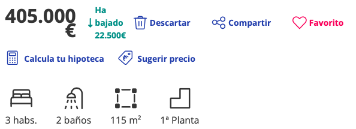

```python
attributes = {}
```

```python
price_text = soup.find('div', class_ = 're-DetailHeader-priceContainer').text.replace('.', '')

price_list = re.findall(r'\d+', price_text)

if len(price_list) > 1:
    attributes['price'] = price_list[0]
    attributes['discount'] = price_list[1]
else:
    attributes['price'] = price_list[0]
    attributes['discount'] = 0
attributes
```

```
{'price': '68000', 'discount': 0}
```

- **Step 2:** Find information contained in the header right below the price (about bedrooms, bath, size and so on). See picture above

```python
fst_detailHeader = soup.find('ul', class_= 're-DetailHeader-features')

# obtain all list inside it
fst_dH_list = fst_detailHeader.find_all('li', class_= 're-DetailHeader-featuresItem')

attributes['elementary'] = []
# get attribute
for element in fst_dH_list:
    attributes['elementary'].append(element.text)

attributes['elementary']
```

```
['4 habs.', '2 baños', '177 m²', '1ª Planta']
```

- **Step 3:** Find Information contained in the second part under '**Catacterísticas**'(here attributes are much better explained)

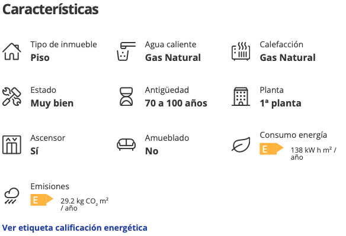

```python
caracter_list = soup.find('div', class_= 're-DetailFeaturesList')

for caracteristica in caracter_list:
    # find <p tags>
    paragraphs = caracteristica.find_all('p')
    attributes[paragraphs[0].text] = paragraphs[1].text
attributes
```

[output not shown]

- **Step 4:** Obtain Extra Infomationen

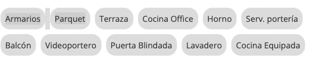

```python
extra_list = soup.find('ul', class_='re-DetailExtras-list').find_all('li')

attributes['extra_tags'] = []

for info in extra_list:
    attributes['extra_tags'].append(info.text)

attributes
```

[output not shown]

- **Step 5:** Find number of reference

```python
ref = soup.find('div', class_= 're-ContactDetail-referenceContainer-wrapper')

attributes['ref'] = ref.find('span').text

# Now we find the tile (address)
address = soup.find('h1').text

attributes['title'] = address
```

```python
attributes
```

[output not shown]

## **2. Scrapper: Spain List of Cities per Population**

```python
url = 'https://es.wikipedia.org/wiki/Anexo:Municipios_de_España_por_población'
response = requests.get(url)

# pase the website to a beautifulsoup object
soup = BeautifulSoup(response.content, 'html.parser')

# Find all the tables:
tables = soup.find_all("table", class_="wikitable")

# create a pandas dataframe to store the values
columns = ['ID', 'Municipality', 'Population', 'Province', 'Region']
df_cities = pd.DataFrame(columns = columns)

data = []

for table in tables:
    rows = table.find_all('tr')
    # Loop over the rows and extract the data for each municipality
    for row in rows[1:]:  # Start from index 1 to skip the header row
        # Find all cells in the row
        cells = row.find_all("td")

        # Extract the data from each cell
        position = cells[0].text.strip()
        municipality = cells[1].text.strip()
        population = int(cells[2].text.strip().replace(' ', ''))
        # code is given us the name of the municipality twice. We only need one of them
        string_len = len(cells[3].text.strip())
        province = cells[3].text.strip()[0:int(string_len/2)]
        try:
            string_len = len(cells[4].text.strip())
            region = cells[4].text.strip()[0:int(string_len/2)]

        except IndexError:
            region = province

        data.append([position, municipality, population, province, region])

df = pd.DataFrame(data = data, columns = columns)
df.set_index('ID', inplace = True)

# Import csv to be used in R.
df.to_csv('../02_RCodes/01_SpainCities.csv')
```

- Let's export the dataframe as a csv.file

### **3 Scrapper: Data About Mean Net Income per Person (Website: [Instituto de Estadística](https://www.ine.es/jaxiT3/Datos.htm?t=31079))**

- This scraper will be used to query the data to google and obtain the number associated with the state on the website 'instituto nacional da estadística'.

[figure not shown]

Here, any example is the number 31097 that uniquely identifies the provinces. After tis procedure, we will use these numbers to build the urls to be requested by `BeautifulSoup`.

```python
# Import the list with the sampled data.
province_list = pd.read_csv('02_SampledCities.csv')['Province'].unique().tolist()
len(province_list)
```

```
51
```

```python
print(province_list, end="")
```

```
['Comunidad de Madrid', 'Santa Cruz de Tenerife', 'Badajoz', 'La Coruña', 'Barcelona', 'Valencia', 'Málaga', 'Vizcaya', 'Cádiz', 'Alicante', 'Pontevedra', 'Región de Murcia', 'Principado de Asturias', 'Castellón', 'Gerona', 'Huelva', 'Islas Baleares', 'Madrid', 'Guipúzcoa', 'Las Palmas', 'Huesca', '…
```

```python
# Make sure
driver = webdriver.Chrome(options=option)
query = "Indicadores de renta media y mediana madrid"
url = "http://www.google.es/search?q=" + query + "&start=" + str(1)
driver.get(url)

numbers = []
dictionary = {}
for province in province_list:
    # Accept cookies
    driver = webdriver.Chrome(options=option)
    query = f"Indicadores de renta media y mediana {province}"
    url = "http://www.google.es/search?q=" + query + "&start=" + str(0)
    driver.get(url)
    try:
        accept_element = driver.find_element(By.ID, "L2AGLb")
        accept_element.click()
    finally:
    # get text elements
        ads = driver.find_elements(By.TAG_NAME, "h3")
        for element in ads:
            if 'renta media y mediana(' in element.text:
                numbers.append(re.findall(r'\d+', element.text)[0])

    time.sleep(1)
    driver.close()
```

- We will only keep the unique numbers:

```python
unique_numbers = list(set(numbers))
print(unique_numbers, end = "")
```

```
['30878', '31016', '31052', '31250', '30971', '31259', '30887', '31034', '53689', '30980', '31079', '30917', '31133', '30851', '31268', '31043', '30944', '31115', '31223', '30656', '30926', '31295', '31106', '31007', '31277', '31286', '30842', '31097', '31178', '31232', '30953', '31124', '30998', '3…
```

```python
len(unique_numbers)
```

```
51
```

- We have the same amount of numbers as provinces.

Now, if you enter the website [instituto nacional de estadístidica](https://www.ine.es/jaxiT3/Datos.htm?t=31079) and analyze its html, we will notice that the number (30878) is related is related to the province Badajoz, and if you change the website to another province, only this number changes. We will use this fact to scrape the table in in using `BeautifulSoup`.

```python
import copy
# make a true copy of the list unique number
queries = copy.copy(unique_numbers)

print(queries, end = "")
```

```
['30878', '31016', '31052', '31250', '30971', '31259', '30887', '31034', '53689', '30980', '31079', '30917', '31133', '30851', '31268', '31043', '30944', '31115', '31223', '30656', '30926', '31295', '31106', '31007', '31277', '31286', '30842', '31097', '31178', '31232', '30953', '31124', '30998', '3…
```

```python
from bs4 import BeautifulSoup
import requests

column_entries = []
failed_queries = []
counter = 0
for number in unique_numbers:
    time.sleep(2)
    url = f'https://www.ine.es/jaxiT3/Datos.htm?t={number}'
    initial_length = len(queries)
    while len(queries) == initial_length:
        response = requests.get(url)

        # parse the url to beautifulsoup
        soup = BeautifulSoup(response.text, 'html.parser')
        try:
            # obtain the name of the province
            province_name = soup.find('span', class_="cab2").text

            # get the tables and the rows returned by the html
            rows = soup.find_all('table')[0].find_all('tr')

            for row in rows:
                columns = row.find_all(['th', 'td'])
                if len(columns) > 1:
                    column_entries.append([columns[0].text, columns[1].text, province_name, number])
                else:
                    column_entries.append([columns[0].text, '', '', ''])

            #every time a query is successful, we wil remove it from the the queries list.
            queries.remove(number)
            counter += 1
            print('success', counter)
        except:
            failed_queries.append(number)
```

```
success 1
success 2
success 3
success 4
success 5
success 6
success 7
success 8
success 9
success 10
success 11
success 12
success 13
success 14
success 15
success 16
success 17
success 18
success 19
success 20
success 21
success 22
success 23
success 24
success 25
success 26
success 27
success 28
success 29
success 30
success 31
success 32
success 33
success 34
success 35
success 36
success 37
success 38
success 39
success 40
success 41
success 42
success 43
success 44
success 45
success 46
success 47
success 48
success 49
success 50
success 51
```

```python
# We now create a pandas dataframe with the information just obtained:
```

[output not shown]

```python
df_renta = pd.DataFrame(data = column_entries, columns = ['Ciudad', 'Renta', 'Provincia', 'Accesso'])
```

```python
df_renta['Ciudad'].split('01')
```

[output not shown]

```python
df_renta[['WebID', 'Municipality']] = df_renta['Ciudad'].str.extract(r'^(\d+)(.*)')

# We now drop all NA values
df_renta.dropna(inplace = True)
```

```python
df_renta
```

|  | Ciudad | Renta | Provincia | Accesso | WebID | Municipality |
| --- | --- | --- | --- | --- | --- | --- |
| 1 | 2020 |  |  |  | 2020 |  |
| 2 | 06001 Acedera | 9.406 | Badajoz | 30878 | 06001 | Acedera |
| 3 | 0600101 Acedera distrito 01 | 9.406 | Badajoz | 30878 | 0600101 | Acedera distrito 01 |
| 4 | 0600101001 Acedera sección 01001 | 9.406 | Badajoz | 30878 | 0600101001 | Acedera sección 01001 |
| 5 | 06002 Aceuchal | 8.008 | Badajoz | 30878 | 06002 | Aceuchal |
| ... | ... | ... | ... | ... | ... | ... |
| 54257 | 3503401002 Yaiza sección 01002 | 7.574 | Palmas, Las | 31151 | 3503401002 | Yaiza sección 01002 |
| 54258 | 3503401003 Yaiza sección 01003 | 8.455 | Palmas, Las | 31151 | 3503401003 | Yaiza sección 01003 |
| 54259 | 3503401004 Yaiza sección 01004 | 9.815 | Palmas, Las | 31151 | 3503401004 | Yaiza sección 01004 |
| 54260 | 3503401005 Yaiza sección 01005 | 8.530 | Palmas, Las | 31151 | 3503401005 | Yaiza sección 01005 |
| 54261 | 3503401006 Yaiza sección 01006 | 10.762 | Palmas, Las | 31151 | 3503401006 | Yaiza sección 01006 |

54049 rows × 6 columns

```python
# Note that we do not want to have distritos or secciones, only municipalities
filt = df_renta['Municipality'].str.contains(r'distrito|sección')
df_renta = df_renta[~filt]
```

```python
# Note that 2020 indicates the year, we do not want to have that either. So we drop all rows where 2020 appears
filt = df_renta['Ciudad'] == '2020'
df_renta = df_renta[~filt]
```

```python
df_renta.reset_index(inplace = True)

df_renta
```

|  | level_0 | index | Ciudad | Renta | Provincia | Accesso | WebID | Municipality |
| --- | --- | --- | --- | --- | --- | --- | --- | --- |
| 0 | 0 | 2 | 06001 Acedera | 9.406 | Badajoz | 30878 | 06001 | Acedera |
| 1 | 1 | 5 | 06002 Aceuchal | 8.008 | Badajoz | 30878 | 06002 | Aceuchal |
| 2 | 2 | 12 | 06003 Ahillones | 10.096 | Badajoz | 30878 | 06003 | Ahillones |
| 3 | 3 | 15 | 06004 Alange | 8.820 | Badajoz | 30878 | 06004 | Alange |
| 4 | 4 | 19 | 06005 Albuera, La | 8.748 | Badajoz | 30878 | 06005 | Albuera, La |
| ... | ... | ... | ... | ... | ... | ... | ... | ... |
| 7698 | 7698 | 54223 | 35030 Tuineje | 10.127 | Palmas, Las | 31151 | 35030 | Tuineje |
| 7699 | 7699 | 54232 | 35031 Valsequillo de Gran Canaria | 11.143 | Palmas, Las | 31151 | 35031 | Valsequillo de Gran Canaria |
| 7700 | 7700 | 54240 | 35032 Valleseco | 11.830 | Palmas, Las | 31151 | 35032 | Valleseco |
| 7701 | 7701 | 54245 | 35033 Vega de San Mateo | 11.099 | Palmas, Las | 31151 | 35033 | Vega de San Mateo |
| 7702 | 7702 | 54254 | 35034 Yaiza | 9.252 | Palmas, Las | 31151 | 35034 | Yaiza |

7703 rows × 8 columns

```python
# We now export the rows that we need to csv.
df_renta[['Municipality', 'Provincia', 'Renta']].to_csv('03_Mean_Salary.csv', index = False)
```

Note that the base url for the tables in the website is:

```
url = https://15mpedia.org/w/index.php?title=Especial:Ask&offset=0&limit=20&q=%5B%5BPage+has+default+form%3A%3AMunicipio%5D%5D+%5B%5Bpaís%3A%3AEspaña%5D%5D&p=format%3Dtable%2Fmainlabel%3DMunicipio&po=%3F%3DMunicipio%23%0A%3FComarca%23-%0A%3FProvincia%0A%3FComunidad+autónoma%3DCC.AA.%0A%3FAltitud%3DAltitud+%28m.s.n.m.%29%0A%3FSuperficie%3DSuperficie+%28km²%29%0A%3FPoblación+en+2019%3DPoblación+%282019%29%0A%3FDensidad+de+población%3DDensidad+%28hab.%2Fkm²%29%0A&sort=superficie&order=desc
```

We are interested specifically in the section `'Ask&offset=0&limit=20'` of the link above. We will set the limit to be displayed to be equal to 500. Each offset will display another 500 cities. In total the offset goes from 0 to 5000. If we query an offset above 5000, the query will return the first page again. We actually would like to obtain the data on the column `superficie`, which we will use to calculate the density per city. We will not use the Density (Densidad) stated in this table, because the information we have about the current population is newer than the one stated in this table (2019 vs. 2022). Population movements is common but surface is in general a stationary measure.

```python
table = soup.find('table')
rows = table.find_all('tr')

data = []

for offset in range(0, 5500, 500):

    url = f'https://15mpedia.org/w/index.php?title=Especial:Ask&offset={str(offset)}&limit=500&q'\
    + '=%5B%5BPage+has+default+form%3A%3AMunicipio%5D%5D+%5B%5Bpaís%3A%3AEspaña'\
    + '%5D%5D&p=format%3Dtable%2Fmainlabel%3DMunicipio&po=%3F%3DMunicipio%23%0A%3F'\
    + 'Comarca%23-%0A%3FProvincia%0A%3FComunidad+autónoma%3DCC.AA.%0A%3FAltitud%3DAlt'\
    + 'itud+%28m.s.n.m.%29%0A%3FSuperficie%3DSuperficie+%28km²%29%0A%3FPoblación+en+'\
    + '2019%3DPoblación+%282019%29%0A%3FDensidad+de+población%3DDensidad+%28hab.%2Fkm²%29%0A&sort=superficie&order=desc#'

    response = requests.get(url)
    soup = BeautifulSoup(response.text, 'html.parser')
    table = soup.find('table')
    rows = table.find_all('tr')
    for row in rows:
        if offset == 0 and len(data) == 0: # We obtain the headers
            contents = row.find_all('th')
        else:
            contents = row.find_all('td')
        row_text = []
        for content in contents:
            row_text.append(content.text)

        data.append(row_text)
# Now we a pandas dataframe with the
df_density = pd.DataFrame(data = data[1:], columns = data[0])
```

```python
# We will now save this dataframe to csv using ';' as the separator. For we would like to import it in R and the , is here used for decimals.
#df_density.to_csv('04_SurfacePerCity.csv', sep = ';')
```

```python
df_density
```

|  | Municipio | Municipio# | Comarca | Provincia | CC.AA. | Altitud (m.s.n.m.) | Superficie (km²) | Población (2019) | Densidad (hab./km²) |
| --- | --- | --- | --- | --- | --- | --- | --- | --- | --- |
| 0 | Cáceres | Cáceres |  | Provincia de Cáceres | Extremadura | 459 | 1.750,23 | 96.126 | 54,92 |
| 1 | Lorca | Lorca | Alto Guadalentín | Provincia de Murcia | Región de Murcia | 353 | 1.675,27 | 94.404 | 56,35 |
| 2 | Badajoz | Badajoz | Tierra de Badajoz | Provincia de Badajoz | Extremadura | 185 | 1.440,37 | 150.702 | 104,63 |
| 3 | Córdoba | Córdoba |  | Provincia de Córdoba | Andalucía | 120 | 1.254,25 | 325.701 | 259,68 |
| 4 | Almodóvar del Campo | Almodóvar del Campo | Campo de Calatrava | Provincia de Ciudad Real | Castilla-La Mancha | 656 | 1.208,27 | 6.027 | 4,99 |
| ... | ... | ... | ... | ... | ... | ... | ... | ... | ... |
| 5505 | Cañizar del Olivar | Cañizar del Olivar | Cuencas Mineras de Aragón | Provincia de Teruel | Aragón | 954 | 22,29 | 100 | 4,49 |
| 5506 | Palomeque | Palomeque | La Sagra (Toledo) | Provincia de Toledo | Castilla-La Mancha | 610 | 22,28 | 971 | 43,58 |
| 5507 | Montclar | Montclar | Berguedá | Provincia de Barcelona | Cataluña | 728 | 22,28 | 136 | 6,1 |
| 5508 | Galaroza | Galaroza |  | Provincia de Huelva | Andalucía | 564 | 22,27 | 1.379 | 61,92 |
| 5509 | Guils de Cerdanya | Guils de Cerdanya | Baja Cerdaña | Provincia de Girona | Cataluña | 1.385 | 22,26 | 537 | 24,12 |

5510 rows × 9 columns